# Interaction

Ian_Curtis

2018/11/27

## Interaction R Part A

### import data

```r
IceCreamExcel <- read_excel('IceCreamExcel.xlsx')
head(IceCreamExcel)
```

```
## # A tibble: 6 x 5
##      id  cons income price  temp
##   <dbl> <dbl>  <dbl> <dbl> <dbl>
## 1    10 0.264     82 0.280    25
## 2    39 0.256     79 0.277    24
## 3     9 0.269     77 0.270    33
## 4    38 0.269     76 0.265    32
## 5    23 0.282     93 0.279    32
## 6    52 0.284     94 0.277    32
```

```r
str(IceCreamExcel)
```

```
## Classes 'tbl_df', 'tbl' and 'data.frame':    58 obs. of  5 variables:
##  $ id    : num  10 39 9 38 23 52 11 40 8 37 ...
##  $ cons  : num  0.264 0.256 0.269 0.269 0.282 0.284 0.288 0.286 0.288 0.289 ...
##  $ income: num  82 79 77 76 93 94 81 82 79 78 ...
##  $ price : num  0.28 0.277 0.27 0.265 0.279 0.277 0.282 0.282 0.267 0.267 ...
##  $ temp  : num  25 24 33 32 32 32 28 28 47 48 ...
```

```r
summary(IceCreamExcel)
```

```
##        id             cons            income          price
##  Min.   : 1.00   Min.   :0.2560   Min.   :76.00   Min.   :0.2540
##  1st Qu.:15.25   1st Qu.:0.3103   1st Qu.:79.25   1st Qu.:0.2700
##  Median :29.50   Median :0.3465   Median :83.00   Median :0.2770
##  Mean   :29.50   Mean   :0.3534   Mean   :84.40   Mean   :0.2764
##  3rd Qu.:43.75   3rd Qu.:0.3860   3rd Qu.:87.75   3rd Qu.:0.2820
##  Max.   :58.00   Max.   :0.4720   Max.   :96.00   Max.   :0.2920
##       temp
##  Min.   :24.00
##  1st Qu.:33.00
##  Median :47.50
##  Mean   :48.55
##  3rd Qu.:63.75
##  Max.   :73.00
```

### exclude variable x(id)

```r
ICD <- subset(IceCreamExcel, select = -c(id))
str(ICD)
```

```
## Classes 'tbl_df', 'tbl' and 'data.frame':    58 obs. of  4 variables:
##  $ cons  : num  0.264 0.256 0.269 0.269 0.282 0.284 0.288 0.286 0.288 0.289 ...
##  $ income: num  82 79 77 76 93 94 81 82 79 78 ...
##  $ price : num  0.28 0.277 0.27 0.265 0.279 0.277 0.282 0.282 0.267 0.267 ...
##  $ temp  : num  25 24 33 32 32 32 28 28 47 48 ...
```

```r
summary(ICD)
```

```
##       cons            income          price             temp
##  Min.   :0.2560   Min.   :76.00   Min.   :0.2540   Min.   :24.00
##  1st Qu.:0.3103   1st Qu.:79.25   1st Qu.:0.2700   1st Qu.:33.00
##  Median :0.3465   Median :83.00   Median :0.2770   Median :47.50
##  Mean   :0.3534   Mean   :84.40   Mean   :0.2764   Mean   :48.55
##  3rd Qu.:0.3860   3rd Qu.:87.75   3rd Qu.:0.2820   3rd Qu.:63.75
##  Max.   :0.4720   Max.   :96.00   Max.   :0.2920   Max.   :73.00
```

### run correlations

```r
cor(ICD)
```

```
##               cons      income       price        temp
## cons    1.00000000 -0.04683888 -0.12709010  0.78761058
## income -0.04683888  1.00000000 -0.11173850 -0.37693836
## price  -0.12709010 -0.11173850  1.00000000 -0.04729122
## temp    0.78761058 -0.37693836 -0.04729122  1.00000000
```

### corr visualization

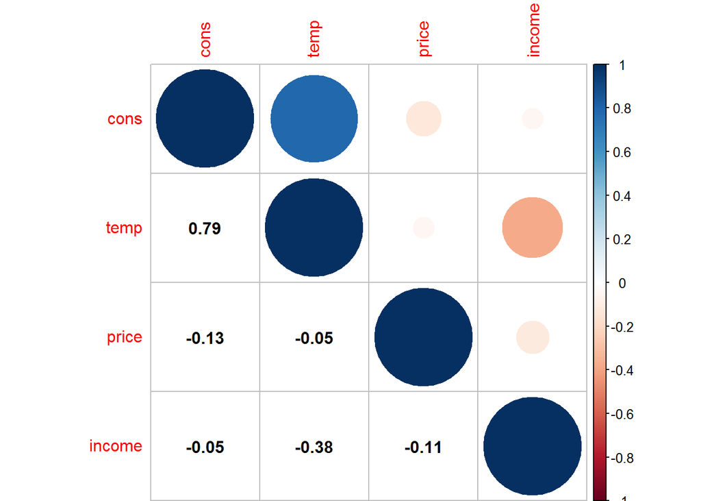

```r
corr <- cor(ICD)
# corrplot::corrplot(corr = corr)
corrplot::corrplot(corr = corr, order = "AOE", tl.pos = "tp")
corrplot::corrplot(corr = corr,
         add = TRUE, type = "lower", method = "number", order = "AOE",
         col = "black", diag = FALSE, tl.pos = "n", cl.pos = "n")
```

The correlations plot only is an another method for explanation of correlation matrix,what it tells us is the same.

### use Hmisc

```r
library(Hmisc)
rcorr(as.matrix(ICD))
```

```
##         cons income price  temp
## cons    1.00  -0.05 -0.13  0.79
## income -0.05   1.00 -0.11 -0.38
## price  -0.13  -0.11  1.00 -0.05
## temp    0.79  -0.38 -0.05  1.00
##
## n= 58
##
##
## P
##        cons   income price  temp
## cons          0.7270 0.3418 0.0000
## income 0.7270        0.4037 0.0035
## price  0.3418 0.4037        0.7245
## temp   0.0000 0.0035 0.7245
```

## Interaction R Part B

### create some new var, run correlations

```r
ICD <- ICD %>% mutate(
    Income_by_price = income * price,
    Income_by_temp  = income * temp ,
    Price_by_temp   = price * temp
) %>% mutate(
    income_mc = scale(income, center = TRUE),
    price_mc  = scale(price, center = TRUE),
    temp_mc   = scale(temp, center = TRUE)
)

summary(ICD)
```

```
##       cons            income          price             temp
##  Min.   :0.2560   Min.   :76.00   Min.   :0.2540   Min.   :24.00
##  1st Qu.:0.3103   1st Qu.:79.25   1st Qu.:0.2700   1st Qu.:33.00
##  Median :0.3465   Median :83.00   Median :0.2770   Median :47.50
##  Mean   :0.3534   Mean   :84.40   Mean   :0.2764   Mean   :48.55
##  3rd Qu.:0.3860   3rd Qu.:87.75   3rd Qu.:0.2820   3rd Qu.:63.75
##  Max.   :0.4720   Max.   :96.00   Max.   :0.2920   Max.   :73.00
##  Income_by_price Income_by_temp Price_by_temp        income_mc.V1
##  Min.   :20.14   Min.   :1896   Min.   : 6.648   Min.   :-1.3880139
##  1st Qu.:22.31   1st Qu.:2984   1st Qu.: 8.876   1st Qu.:-0.8507642
##  Median :23.27   Median :3834   Median :12.848   Median :-0.2308606
##  Mean   :23.32   Mean   :4062   Mean   :13.414   Mean   : 0.0000000
##  3rd Qu.:24.63   3rd Qu.:5157   3rd Qu.:17.485   3rd Qu.: 0.5543505
##  Max.   :26.79   Max.   :5915   Max.   :20.586   Max.   : 1.9181383
##      price_mc.V1           temp_mc.V1
##  Min.   :-2.7027504   Min.   :-1.5277786
##  1st Qu.:-0.7734024   1st Qu.:-0.9677362
##  Median : 0.0706873   Median :-0.0654456
##  Mean   : 0.0000000   Mean   : 0.0000000
##  3rd Qu.: 0.6736085   3rd Qu.: 0.9457422
##  Max.   : 1.8794510   Max.   : 1.5213414
```

```r
rcorr(as.matrix(ICD))
```

```
##                  cons income price  temp Income_by_price Income_by_temp
## cons             1.00  -0.05 -0.13  0.79           -0.11           0.82
## income          -0.05   1.00 -0.11 -0.38            0.91          -0.19
## price           -0.13  -0.11  1.00 -0.05            0.31          -0.08
## temp             0.79  -0.38 -0.05  1.00           -0.39           0.98
## Income_by_price -0.11   0.91  0.31 -0.39            1.00          -0.23
## Income_by_temp   0.82  -0.19 -0.08  0.98           -0.23           1.00
## Price_by_temp    0.78  -0.39  0.04  1.00           -0.36           0.97
## income_mc       -0.05   1.00 -0.11 -0.38            0.91          -0.19
## price_mc        -0.13  -0.11  1.00 -0.05            0.31          -0.08
## temp_mc          0.79  -0.38 -0.05  1.00           -0.39           0.98
##                 Price_by_temp income_mc price_mc temp_mc
## cons                     0.78     -0.05    -0.13    0.79
## income                  -0.39      1.00    -0.11   -0.38
## price                    0.04     -0.11     1.00   -0.05
## temp                     1.00     -0.38    -0.05    1.00
## Income_by_price         -0.36      0.91     0.31   -0.39
## Income_by_temp           0.97     -0.19    -0.08    0.98
## Price_by_temp            1.00     -0.39     0.04    1.00
## income_mc               -0.39      1.00    -0.11   -0.38
## price_mc                 0.04     -0.11     1.00   -0.05
## temp_mc                  1.00     -0.38    -0.05    1.00
##
## n= 58
##
##
## P
##                 cons   income price  temp   Income_by_price Income_by_temp
## cons                   0.7270 0.3418 0.0000 0.4067          0.0000
## income          0.7270        0.4037 0.0035 0.0000          0.1529
## price           0.3418 0.4037        0.7245 0.0188          0.5261
## temp            0.0000 0.0035 0.7245        0.0025          0.0000
## Income_by_price 0.4067 0.0000 0.0188 0.0025                 0.0865
## Income_by_temp  0.0000 0.1529 0.5261 0.0000 0.0865
## Price_by_temp   0.0000 0.0025 0.7590 0.0000 0.0049          0.0000
## income_mc       0.7270 0.0000 0.4037 0.0035 0.0000          0.1529
## price_mc        0.3418 0.4037 0.0000 0.7245 0.0188          0.5261
## temp_mc         0.0000 0.0035 0.7245 0.0000 0.0025          0.0000
##                 Price_by_temp income_mc price_mc temp_mc
## cons            0.0000        0.7270    0.3418   0.0000
## income          0.0025        0.0000    0.4037   0.0035
## price           0.7590        0.4037    0.0000   0.7245
## temp            0.0000        0.0035    0.7245   0.0000
## Income_by_price 0.0049        0.0000    0.0188   0.0025
## Income_by_temp  0.0000        0.1529    0.5261   0.0000
## Price_by_temp                 0.0025    0.7590   0.0000
## income_mc       0.0025                  0.4037   0.0035
## price_mc        0.7590        0.4037             0.7245
## temp_mc         0.0000        0.0035    0.7245
```

### create two_way interaction terms and view corr

```r
ICD <- ICD %>% mutate(
    Income_by_price = income_mc * price_mc,
    Income_by_temp  = income_mc * temp_mc ,
    Price_by_temp   = price_mc * temp_mc
)

summary(ICD)
```

```
##       cons            income          price             temp
##  Min.   :0.2560   Min.   :76.00   Min.   :0.2540   Min.   :24.00
##  1st Qu.:0.3103   1st Qu.:79.25   1st Qu.:0.2700   1st Qu.:33.00
##  Median :0.3465   Median :83.00   Median :0.2770   Median :47.50
##  Mean   :0.3534   Mean   :84.40   Mean   :0.2764   Mean   :48.55
##  3rd Qu.:0.3860   3rd Qu.:87.75   3rd Qu.:0.2820   3rd Qu.:63.75
##  Max.   :0.4720   Max.   :96.00   Max.   :0.2920   Max.   :73.00
##  Income_by_price.V1   Income_by_temp.V1     Price_by_temp.V1
##  Min.   :-5.184249   Min.   :-2.2416441   Min.   :-1.8871213
##  1st Qu.:-0.366100   1st Qu.:-1.0429021   1st Qu.:-0.6270359
##  Median :-0.063060   Median :-0.2647573   Median : 0.0446646
##  Mean   :-0.109812   Mean   :-0.3704394   Mean   :-0.0464759
##  3rd Qu.: 0.625419   3rd Qu.: 0.1130087   3rd Qu.: 0.5054885
##  Max.   : 1.910356   Max.   : 1.4296031   Max.   : 1.4175626
##      income_mc.V1         price_mc.V1           temp_mc.V1
##  Min.   :-1.3880139   Min.   :-2.7027504   Min.   :-1.5277786
##  1st Qu.:-0.8507642   1st Qu.:-0.7734024   1st Qu.:-0.9677362
##  Median :-0.2308606   Median : 0.0706873   Median :-0.0654456
##  Mean   : 0.0000000   Mean   : 0.0000000   Mean   : 0.0000000
##  3rd Qu.: 0.5543505   3rd Qu.: 0.6736085   3rd Qu.: 0.9457422
##  Max.   : 1.9181383   Max.   : 1.8794510   Max.   : 1.5213414
```

```r
rcorr(as.matrix(ICD))
```

```
##                  cons income price  temp Income_by_price Income_by_temp
## cons             1.00  -0.05 -0.13  0.79           -0.39          -0.21
## income          -0.05   1.00 -0.11 -0.38           -0.49          -0.26
## price           -0.13  -0.11  1.00 -0.05            0.26          -0.12
## temp             0.79  -0.38 -0.05  1.00           -0.09          -0.12
## Income_by_price -0.39  -0.49  0.26 -0.09            1.00          -0.09
## Income_by_temp  -0.21  -0.26 -0.12 -0.12           -0.09           1.00
## Price_by_temp    0.22  -0.13 -0.09  0.12           -0.31           0.07
## income_mc       -0.05   1.00 -0.11 -0.38           -0.49          -0.26
## price_mc        -0.13  -0.11  1.00 -0.05            0.26          -0.12
## temp_mc          0.79  -0.38 -0.05  1.00           -0.09          -0.12
##                 Price_by_temp income_mc price_mc temp_mc
## cons                     0.22     -0.05    -0.13    0.79
## income                  -0.13      1.00    -0.11   -0.38
## price                   -0.09     -0.11     1.00   -0.05
## temp                     0.12     -0.38    -0.05    1.00
## Income_by_price         -0.31     -0.49     0.26   -0.09
## Income_by_temp           0.07     -0.26    -0.12   -0.12
## Price_by_temp            1.00     -0.13    -0.09    0.12
## income_mc               -0.13      1.00    -0.11   -0.38
## price_mc                -0.09     -0.11     1.00   -0.05
## temp_mc                  0.12     -0.38    -0.05    1.00
##
## n= 58
##
##
## P
##                 cons   income price  temp   Income_by_price Income_by_temp
## cons                   0.7270 0.3418 0.0000 0.0023          0.1100
## income          0.7270        0.4037 0.0035 0.0000          0.0530
## price           0.3418 0.4037        0.7245 0.0510          0.3822
## temp            0.0000 0.0035 0.7245        0.5115          0.3597
## Income_by_price 0.0023 0.0000 0.0510 0.5115                 0.5042
## Income_by_temp  0.1100 0.0530 0.3822 0.3597 0.5042
## Price_by_temp   0.1024 0.3219 0.5146 0.3738 0.0172          0.6167
## income_mc       0.7270 0.0000 0.4037 0.0035 0.0000          0.0530
## price_mc        0.3418 0.4037 0.0000 0.7245 0.0510          0.3822
## temp_mc         0.0000 0.0035 0.7245 0.0000 0.5115          0.3597
##                 Price_by_temp income_mc price_mc temp_mc
## cons            0.1024        0.7270    0.3418   0.0000
## income          0.3219        0.0000    0.4037   0.0035
## price           0.5146        0.4037    0.0000   0.7245
## temp            0.3738        0.0035    0.7245   0.0000
## Income_by_price 0.0172        0.0000    0.0510   0.5115
## Income_by_temp  0.6167        0.0530    0.3822   0.3597
## Price_by_temp                 0.3219    0.5146   0.3738
## income_mc       0.3219                  0.4037   0.0035
## price_mc        0.5146        0.4037             0.7245
## temp_mc         0.3738        0.0035    0.7245
```

This step add variable interaction term in raw data.

## Interaction R Part C

### testing linear model w/no interactions

```r
model <- lm(cons ~ income + price + temp, data = ICD)
summary(model)
```

```
##
## Call:
## lm(formula = cons ~ income + price + temp, data = ICD)
##
## Residuals:
##       Min        1Q    Median        3Q       Max
## -0.059146 -0.018587  0.007452  0.018436  0.071937
##
## Coefficients:
##               Estimate Std. Error t value Pr(>|t|)
## (Intercept)  0.0819503  0.1662346   0.493  0.62403
## income       0.0026093  0.0007533   3.464  0.00105 **
## price       -0.3575747  0.5095112  -0.702  0.48582
## temp         0.0030912  0.0002821  10.958 2.43e-15 ***
## ---
## Signif. codes:  0 '***' 0.001 '**' 0.01 '*' 0.05 '.' 0.1 ' ' 1
##
## Residual standard error: 0.03155 on 54 degrees of freedom
## Multiple R-squared:  0.696,  Adjusted R-squared:  0.6791
## F-statistic: 41.21 on 3 and 54 DF,  p-value: 5.46e-14
```

```r
library(car)

vif(model)
```

```
##   income    price     temp
## 1.188929 1.022290 1.176717
```

According to the result of this model,and the function **Vif** ,which compute each variable’s **Variance Inflation Factors**;and vif value in each variable is smaller than 10,which mean that collinearity in model does not exist.And the *R.Square* in thsis model is about **0.68**.

```r
model1 <- lm(cons ~ income + price + temp + Income_by_temp +
                 Income_by_price + Price_by_temp, data = ICD)
summary(model1)
```

```
##
## Call:
## lm(formula = cons ~ income + price + temp + Income_by_temp +
##     Income_by_price + Price_by_temp, data = ICD)
##
## Residuals:
##       Min        1Q    Median        3Q       Max
## -0.055437 -0.014994 -0.001467  0.014653  0.075777
##
## Coefficients:
##                   Estimate Std. Error t value Pr(>|t|)
## (Intercept)      0.1940702  0.1684847   1.152   0.2548
## income           0.0007633  0.0010230   0.746   0.4590
## price           -0.1412090  0.4870840  -0.290   0.7731
## temp             0.0026738  0.0003001   8.910 5.66e-12 ***
## Income_by_temp  -0.0079020  0.0050423  -1.567   0.1233
## Income_by_price -0.0127447  0.0048355  -2.636   0.0111 *
## Price_by_temp    0.0040494  0.0055626   0.728   0.4700
## ---
## Signif. codes:  0 '***' 0.001 '**' 0.01 '*' 0.05 '.' 0.1 ' ' 1
##
## Residual standard error: 0.02927 on 51 degrees of freedom
## Multiple R-squared:  0.7529, Adjusted R-squared:  0.7239
## F-statistic:  25.9 on 6 and 51 DF,  p-value: 6.96e-14
```

```r
vif(model1)
```

```
##          income           price            temp  Income_by_temp
##        2.548701        1.085771        1.547520        1.358149
## Income_by_price   Price_by_temp
##        2.206110        1.288576
```

This new model add interaction term.Accordding to the summary of the new model,we can know that all predictors’**Variance Inflation Factors** in this model ara still smaller than 10,which mean that collinearity in new model does not exist too,but in **R.Square** is about **0.72**,that is to said this model perform better than origin model.

### testing linear model w/no interactions using pequod

```r
library(pequod)

modelpe <- lmres(cons ~ income + price + temp, data = ICD)
summary(modelpe)
```

```
## Formula:
## cons ~ income + price + temp
## <environment: 0x00000000133aa178>
##
## Models
##          R     R^2   Adj. R^2    F     df1  df2  p.value
## Model  0.834  0.696     0.679 41.206  3.000   54 5.5e-14 ***
## ---
## Signif. codes:  0 '***' 0.001 '**' 0.01 '*' 0.05 '.' 0.1 ' ' 1
##
## Residuals
##    Min. 1st Qu.  Median    Mean 3rd Qu.    Max.
## -0.0591 -0.0186  0.0075  0.0000  0.0184  0.0719
##
## Coefficients
##             Estimate   StdErr  t.value    beta p.value
## (Intercept)  0.08195  0.16623  0.49298         0.62403
## income       0.00261  0.00075  3.46405  0.2834 0.00105 **
## price       -0.35757  0.50951 -0.70180 -0.0532 0.48582
## temp         0.00309  0.00028 10.95810  0.8919 < 2e-16 ***
## ---
## Signif. codes:  0 '***' 0.001 '**' 0.01 '*' 0.05 '.' 0.1 ' ' 1
##
## Collinearity
##           VIF Tolerance
## income 1.1889    0.8411
## price  1.0223    0.9782
## temp   1.1767    0.8498
```

```r
modelpe1 <- lmres(cons ~ income * price + income * temp + price * temp,
                 centered = c("income", "price", "temp"), data = ICD)
summary(modelpe1)
```

```
## Formula:
## cons ~ income + price + temp + income.XX.price + income.XX.temp +
##     price.XX.temp
## <environment: 0x0000000016aa8c68>
##
## Models
##          R     R^2   Adj. R^2    F     df1  df2  p.value
## Model  0.868  0.753     0.724 25.904  6.000   51   7e-14 ***
## ---
## Signif. codes:  0 '***' 0.001 '**' 0.01 '*' 0.05 '.' 0.1 ' ' 1
##
## Residuals
##    Min. 1st Qu.  Median    Mean 3rd Qu.    Max.
## -0.0554 -0.0150 -0.0015  0.0000  0.0147  0.0758
##
## Coefficients
##                 Estimate   StdErr  t.value    beta p.value
## (Intercept)      0.34928  0.00442 78.94223          <2e-16 ***
## income           0.00076  0.00102  0.74609  0.0829  0.4590
## price           -0.14121  0.48708 -0.28991 -0.0210  0.7731
## temp             0.00267  0.00030  8.91026  0.7715  <2e-16 ***
## income.XX.price -0.25405  0.09639 -2.63563 -0.2725  0.0111 *
## income.XX.temp  -0.00008  0.00005 -1.56715 -0.1271  0.1233
## price.XX.temp    0.03038  0.04174  0.72796  0.0575  0.4700
## ---
## Signif. codes:  0 '***' 0.001 '**' 0.01 '*' 0.05 '.' 0.1 ' ' 1
##
## Collinearity
##                    VIF Tolerance
## income          2.5487    0.3924
## price           1.0858    0.9210
## temp            1.5475    0.6462
## income.XX.price 2.2061    0.4533
## income.XX.temp  1.3581    0.7363
## price.XX.temp   1.2886    0.7761
```

In model that lack of interactions,the coefficient of *income* and *temp* is significant,and these two variables both has positive effect on response *cons*;But in the model that add interactions,the coefficient of *itercept*,*temp* and *iteraction of income and price* are significant.The coefficient result change,but the latter model perform better based on *R.Square*.However,the coefficient of interaction is greater than other,and is is negative,that is ,the interaction has a more greater effect on response.And the comparion between the two model,interaction term should add in linear model.

## Interaction R Part D

### Simple slope test and plot for income by price interatcion

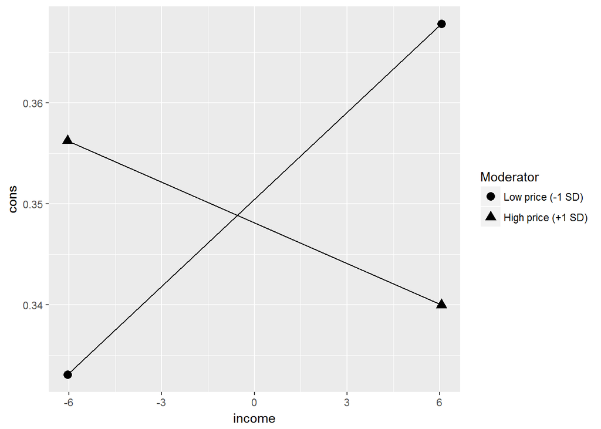

```r
S_slopes <- simpleSlope(modelpe1, pred = "income", mod1 = "price")
PLotIncome_by_proce <- PlotSlope(S_slopes)
PLotIncome_by_proce
```

```r
summary(S_slopes)
```

```
##
## ** Estimated points of cons  **
##
##                    Low income (-1 SD) High income (+1 SD)
## Low price (-1 SD)              0.3331              0.3678
## High price (+1 SD)             0.3562              0.3400
##
##
##
## ** Simple Slopes analysis ( df= 51 ) **
##
##                    simple slope standard error t-value p.value
## Low price (-1 SD)        0.0029         0.0008    3.79  0.0004 ***
## High price (+1 SD)      -0.0013         0.0017   -0.80  0.4257
## ---
## Signif. codes:  0 '***' 0.001 '**' 0.01 '*' 0.05 '.' 0.1 ' ' 1
##
##
##
## ** Bauer & Curran 95% CI **
##
##       lower CI upper CI
## price  -0.0034   0.0348
```

The result show us that,the slope is significant when price is low,and is not sigificant when price is high.And the *cons* change whether is positive or not is effect signifivantly by price

## Interaction R Part E

### creating and testing:

testing three-way interactions without pequod, note use of maen center predictors

```r
ICD <- ICD %>% mutate(threeway = income_mc * price_mc * temp_mc)
model2 <- lm(cons ~ income + price + temp + Income_by_temp +
                 Income_by_price + Price_by_temp + threeway, data = ICD)
summary(model2)
```

```
##
## Call:
## lm(formula = cons ~ income + price + temp + Income_by_temp +
##     Income_by_price + Price_by_temp + threeway, data = ICD)
##
## Residuals:
##       Min        1Q    Median        3Q       Max
## -0.053020 -0.010476 -0.000138  0.015241  0.069999
##
## Coefficients:
##                   Estimate Std. Error t value Pr(>|t|)
## (Intercept)      0.4371217  0.1794095   2.436 0.018436 *
## income          -0.0003607  0.0010364  -0.348 0.729238
## price           -0.6627874  0.4916374  -1.348 0.183695
## temp             0.0025004  0.0002876   8.694 1.43e-11 ***
## Income_by_temp  -0.0141126  0.0052022  -2.713 0.009125 **
## Income_by_price -0.0175438  0.0048328  -3.630 0.000666 ***
## Price_by_temp    0.0014251  0.0052917   0.269 0.788793
## threeway        -0.0141151  0.0049541  -2.849 0.006349 **
## ---
## Signif. codes:  0 '***' 0.001 '**' 0.01 '*' 0.05 '.' 0.1 ' ' 1
##
## Residual standard error: 0.02742 on 50 degrees of freedom
## Multiple R-squared:  0.7874, Adjusted R-squared:  0.7577
## F-statistic: 26.46 on 7 and 50 DF,  p-value: 9.665e-15
```

```r
vif(model2)
```

```
##          income           price            temp  Income_by_temp
##        2.980614        1.260545        1.620030        1.647387
## Income_by_price   Price_by_temp        threeway
##        2.511157        1.328835        1.431312
```

```r
modelpe2 <-  lmres(cons ~ income * price * temp,
                 centered = c("income", "price", "temp"), data = ICD)
summary(modelpe2)
```

```
## Formula:
## cons ~ income + price + temp + income.XX.price + income.XX.temp +
##     price.XX.temp + income.XX.price.XX.temp
## <environment: 0x000000000c44fd70>
##
## Models
##          R     R^2   Adj. R^2    F     df1  df2  p.value
## Model  0.887  0.787     0.758 26.461  7.000   50 9.7e-15 ***
## ---
## Signif. codes:  0 '***' 0.001 '**' 0.01 '*' 0.05 '.' 0.1 ' ' 1
##
## Residuals
##    Min. 1st Qu.  Median    Mean 3rd Qu.    Max.
## -0.0530 -0.0105 -0.0001  0.0000  0.0152  0.0700
##
## Coefficients
##                         Estimate   StdErr  t.value    beta p.value
## (Intercept)              0.34487  0.00442 77.96730         < 2e-16 ***
## income                  -0.00036  0.00104 -0.34808 -0.0392 0.72924
## price                   -0.66279  0.49164 -1.34812 -0.0987 0.18369
## temp                     0.00250  0.00029  8.69365  0.7215 < 2e-16 ***
## income.XX.price         -0.34971  0.09633 -3.63015 -0.3751 0.00067 ***
## income.XX.temp          -0.00015  0.00005 -2.71283 -0.2270 0.00913 **
## price.XX.temp            0.01069  0.03971  0.26932  0.0202 0.78879
## income.XX.price.XX.temp -0.01751  0.00615 -2.84915 -0.2222 0.00635 **
## ---
## Signif. codes:  0 '***' 0.001 '**' 0.01 '*' 0.05 '.' 0.1 ' ' 1
##
## Collinearity
##                            VIF Tolerance
## income                  2.9806    0.3355
## price                   1.2605    0.7933
## temp                    1.6200    0.6173
## income.XX.price         2.5112    0.3982
## income.XX.temp          1.6474    0.6070
## price.XX.temp           1.3288    0.7525
## income.XX.price.XX.temp 1.4313    0.6987
```

According to the models show us that,the result is the model with threeway interaction perform better based on *R.Square*,The *R.Square* is about 0.75.And other resultr is simliar with the model with twoway interaction.However,in this time,the coefficinet of interaction of income_price,income_temp,income_price_temp are sigificant,and the effect of them are all negative on response.

### Simple slope test and plot for the three-way interatcion

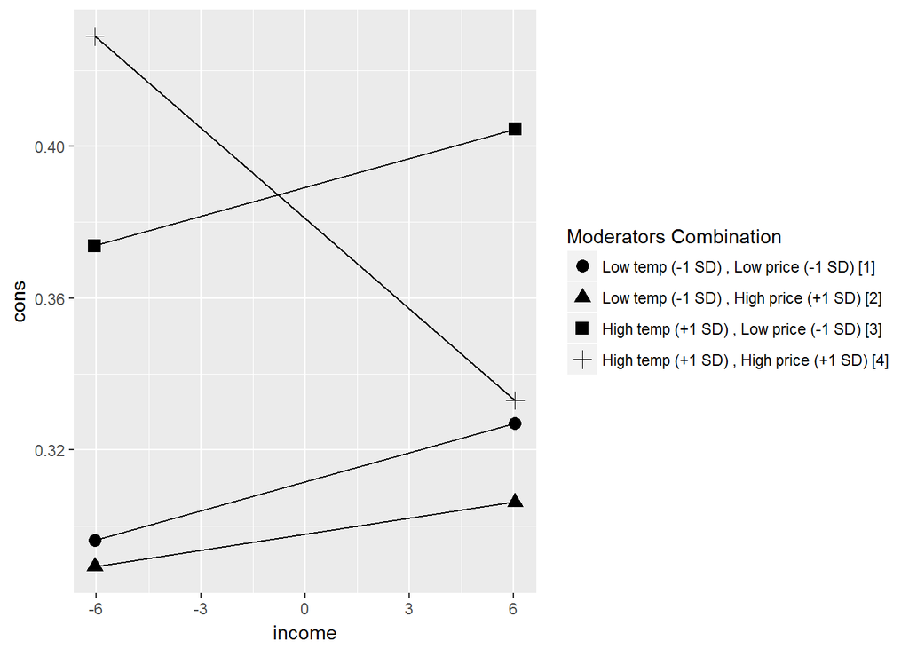

```r
S_slopes_3way <- simpleSlope(modelpe2, pred = "income", mod1 = "temp", mod2 = "price")
Plot_threeway <- PlotSlope(S_slopes_3way)
Plot_threeway
```

```r
summary(S_slopes_3way)
```

```
##
## ** Estimated points of cons  **
##
##                                            Low income (-1 SD)
## Low temp (-1 SD) , Low price (-1 SD) [1]               0.2963
## Low temp (-1 SD) , High price (+1 SD) [2]              0.2893
## High temp (+1 SD) , Low price (-1 SD) [3]              0.3738
## High temp (+1 SD) , High price (+1 SD) [4]             0.4289
##                                            High income (+1 SD)
## Low temp (-1 SD) , Low price (-1 SD) [1]                0.3270
## Low temp (-1 SD) , High price (+1 SD) [2]               0.3063
## High temp (+1 SD) , Low price (-1 SD) [3]               0.4045
## High temp (+1 SD) , High price (+1 SD) [4]              0.3330
##
##
##
## ** Simple Slopes analysis ( df= 50 ) **
##
##                                            simple slope standard error
## Low temp (-1 SD) , Low price (-1 SD) [1]         0.0025         0.0011
## Low temp (-1 SD) , High price (+1 SD) [2]        0.0014         0.0015
## High temp (+1 SD) , Low price (-1 SD) [3]        0.0025         0.0012
## High temp (+1 SD) , High price (+1 SD) [4]      -0.0079         0.0028
##                                            t-value p.value
## Low temp (-1 SD) , Low price (-1 SD) [1]      2.37  0.0214 *
## Low temp (-1 SD) , High price (+1 SD) [2]     0.95  0.3449
## High temp (+1 SD) , Low price (-1 SD) [3]     2.05  0.0452 *
## High temp (+1 SD) , High price (+1 SD) [4]   -2.87  0.0061 **
## ---
## Signif. codes:  0 '***' 0.001 '**' 0.01 '*' 0.05 '.' 0.1 ' ' 1
##
##
##
## ** Slope Difference Test (( df= 50 ); Dawson & Richter, 2006) **
##                                                                                            t-value
## High temp (+1 SD) , High price (+1 SD) [4]  vs.  High temp (+1 SD) , Low price (-1 SD) [3] -3.9393
## High temp (+1 SD) , High price (+1 SD) [4]  vs.  Low temp (-1 SD) , High price (+1 SD) [2] -3.2992
## High temp (+1 SD) , High price (+1 SD) [4]  vs.  Low temp (-1 SD) , Low price (-1 SD) [1]  -3.6964
## High temp (+1 SD) , Low price (-1 SD) [3]  vs.  Low temp (-1 SD) , Low price (-1 SD) [1]    0.0003
## High temp (+1 SD) , Low price (-1 SD) [3]  vs.  Low temp (-1 SD) , High price (+1 SD) [2]   0.6544
```

[output cut: 9 more lines]

```
## High temp (+1 SD) , High price (+1 SD) [4]  vs.  High temp (+1 SD) , Low price (-1 SD) [3]           0.0015
## High temp (+1 SD) , High price (+1 SD) [4]  vs.  Low temp (-1 SD) , High price (+1 SD) [2]           0.0108
## High temp (+1 SD) , High price (+1 SD) [4]  vs.  Low temp (-1 SD) , Low price (-1 SD) [1]            0.0033
## High temp (+1 SD) , Low price (-1 SD) [3]  vs.  Low temp (-1 SD) , Low price (-1 SD) [1]             1.0000
## High temp (+1 SD) , Low price (-1 SD) [3]  vs.  Low temp (-1 SD) , High price (+1 SD) [2]            1.0000
## Low temp (-1 SD) , High price (+1 SD) [2]  vs.  Low temp (-1 SD) , Low price (-1 SD) [1]             1.0000
##
## High temp (+1 SD) , High price (+1 SD) [4]  vs.  High temp (+1 SD) , Low price (-1 SD) [3] **
## High temp (+1 SD) , High price (+1 SD) [4]  vs.  Low temp (-1 SD) , High price (+1 SD) [2] *
## High temp (+1 SD) , High price (+1 SD) [4]  vs.  Low temp (-1 SD) , Low price (-1 SD) [1]  **
## High temp (+1 SD) , Low price (-1 SD) [3]  vs.  Low temp (-1 SD) , Low price (-1 SD) [1]
## High temp (+1 SD) , Low price (-1 SD) [3]  vs.  Low temp (-1 SD) , High price (+1 SD) [2]
## Low temp (-1 SD) , High price (+1 SD) [2]  vs.  Low temp (-1 SD) , Low price (-1 SD) [1]
## ---
## Signif. codes:  0 '***' 0.001 '**' 0.01 '*' 0.05 '.' 0.1 ' ' 1
```

According to the result of this test,the slope change sinifcant when temp,price change,which indicates that the *cons* is mianly effect by *income* and *temp*